# Hosun 7월 2주 과제

# if문

if (logical expression) { statements } else { alternative statements } 만약 logical expression이 참일 때는 statements 문이 실행된다. 반대로 거짓일때는 alternative statements가 실행된다.

### if문 예제

a > 5이고 b > 5이면 a+b를 출력하는 if문을 만드시오. (a = 10, b = 20)

```r
a <- 10
b <- 20
if(a > 5 & b > 5) {
  print(a+b)
}
```

```
## [1] 30
```

### if문 예제

a > 10이거나 b < 20이면 a*b를 출력하는 if문을 만드시오. (a = 10, b = 15)

```r
a <- 10
b <- 15

if(a > 10 | b < 20) {
  print(a*b)
}
```

```
## [1] 150
```

### else if문 예제

1. 조건1을 만족하면 결과1을 출력하고 그렇지 않으면 결과2를 출력하시오.
   - if(조건1){결과1} else {결과2}
2. 조건1을 만족하면 결과1을 출력하고 조건2를 만족하면 결과2를, 그것도 아니면 결과3을 출력하시오.
   - if(조건1){결과1} else if (조건2){결과2} else {결과3}

a 가 5보다 작으면 ’a’를 출력하고 5 이상 10 미만이면 ’b’를 출력, 10이상이면 ’c’를 출력하는 if문을 작성하시오. (a = 12)

```r
a <- 12

if(a < 5) {
  print("a")
}else if (5 <= a & a < 10){
  print("b")
}else {
  print("c")
}
```

```
## [1] "c"
```

## 실습1

a가 3보다 크면 ’3보다 큰 수’를 출력하고 3과 같으면 ’3’을 출력하고 3보다 작으면 ’3보다 작은 수’를 출력하는 if문을 작성하시오.

```r
a <- 2
if(a > 3) {
  print("3보다 큰수")
}else if (a == 3) {
  print("3")
}else {
  print("3보다 작은 수")
}
```

```
## [1] "3보다 작은 수"
```

## 실습2

MASS 패키지 안에 있는 데이터 “Animals”를 이용해 다음을 구하시오. - Animals 데이터를 열에 대한 plot을 구해서 데이터의 분포를 확인하시오.

```r
library(MASS)
head(Animals)
```

```
##                     body brain
## Mountain beaver     1.35   8.1
## Cow               465.00 423.0
## Grey wolf          36.33 119.5
## Goat               27.66 115.0
## Guinea pig          1.04   5.5
## Dipliodocus     11700.00  50.0
```

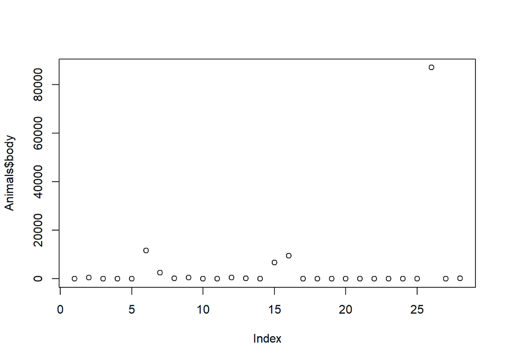

```r
plot(Animals$body)
```

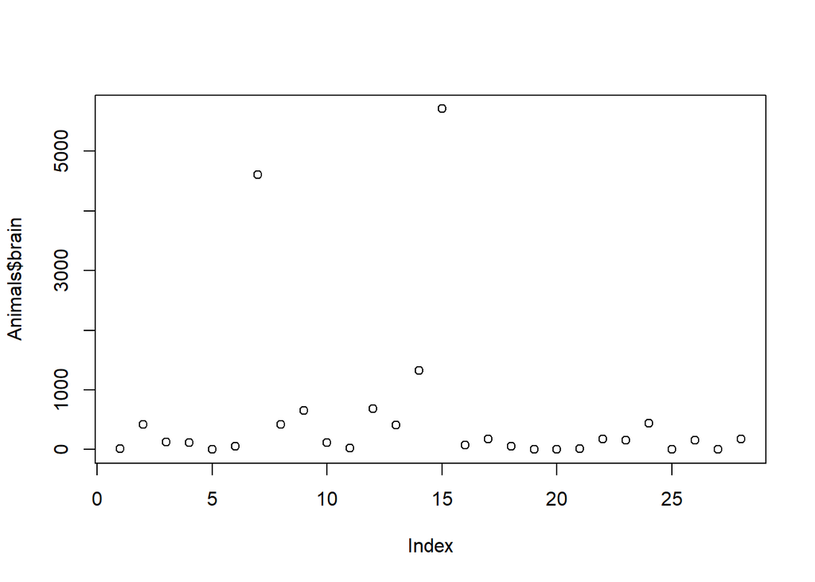

```r
plot(Animals$brain)
```

```r
Mean <- apply(Animals, 2, mean)

for(i in 1:nrow(Animals)){
 if(Animals$body[i] > Mean[1]) {
   Animals$G_body[i] <- "big"
 }else if(Animals$body[i] == Mean[1]) {
   Animals$G_body[i] <- "mean"
 }else {
   Animals$G_body[i] <- "small"
 }
}

head(Animals)
```

```
##                     body brain G_body
## Mountain beaver     1.35   8.1  small
## Cow               465.00 423.0  small
## Grey wolf          36.33 119.5  small
## Goat               27.66 115.0  small
## Guinea pig          1.04   5.5  small
## Dipliodocus     11700.00  50.0    big
```

# 반복문 활용하기 : for문, while문

- for문 : 입력된 벡터의 길이만큼 반복
- while문 : 조건에 따라 반복 -> 반복 횟수를 정확히 모를 떄 사용하면 편리함.

## for문

for ( i in 벡터) { i(원소)를 활용한 실행 구문 }

## 예제

for구문을 활용한 간단한 예제 (누적합 계산) - 1 ~ 10의 누적합을 구하시오. - 1 ~ 10의 합을 구하시오.

```r
# 누적합
cumsum <- 0 #sum의 초기값 지정
for ( i in 1: 10) {
  cumsum <- cumsum + i
  print(cumsum)
}
```

```
## [1] 1
## [1] 3
## [1] 6
## [1] 10
## [1] 15
## [1] 21
## [1] 28
## [1] 36
## [1] 45
## [1] 55
```

```r
# 합
sum <- 0
for ( i in 1:10) {
  sum <- sum + i
}
sum
```

```
## [1] 55
```